# Non-linear Models

This notebook illustrates the following techniques: Principal component analysis Cluster Analysis Decision / Classification trees

```r
toypc <- read.csv("Toy Princomp.dat")
summary(toypc)
```

```
       x               z              y
 Min.   :1.000   Min.   :1.50   Min.   : 4.900
 1st Qu.:2.025   1st Qu.:2.35   1st Qu.: 6.575
 Median :2.900   Median :2.95   Median : 8.600
 Mean   :2.690   Mean   :2.88   Mean   :10.330
 3rd Qu.:3.350   3rd Qu.:3.50   3rd Qu.:14.950
 Max.   :4.500   Max.   :4.10   Max.   :17.700
```

```r
cor(toypc)
```

```
          x         z         y
x 1.0000000 0.5752099 0.7142699
z 0.5752099 1.0000000 0.7911656
y 0.7142699 0.7911656 1.0000000
```

```r
fit <- princomp(toypc[,-3],cor=T)
summary(fit)
```

```
Importance of components:
                         Comp.1    Comp.2
Standard deviation     1.255074 0.6517592
Proportion of Variance 0.787605 0.2123950
Cumulative Proportion  0.787605 1.0000000
```

```r
fit$loadings
```

```
Loadings:
  Comp.1 Comp.2
x  0.707 -0.707
z  0.707  0.707

               Comp.1 Comp.2
SS loadings       1.0    1.0
Proportion Var    0.5    0.5
Cumulative Var    0.5    1.0
```

```r
1.255074^2 + 0.6517592^2
```

```
[1] 2.000001
```

```r
loadings(fit) # pc loadings
```

```
Loadings:
  Comp.1 Comp.2
x  0.707 -0.707
z  0.707  0.707

               Comp.1 Comp.2
SS loadings       1.0    1.0
Proportion Var    0.5    0.5
Cumulative Var    0.5    1.0
```

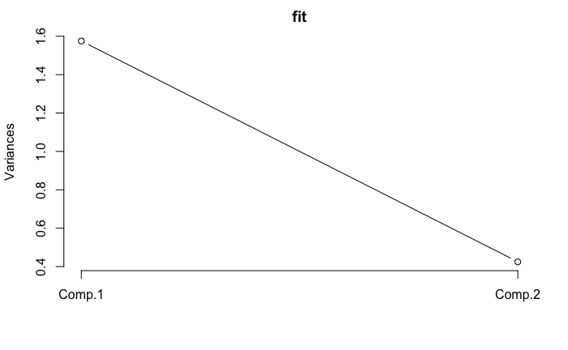

```r
plot(fit,type="lines") # scree plot
```

```r
fit$scores # the principal components
```

```
          Comp.1      Comp.2
 [1,]  0.2531936 -0.86105747
 [2,] -2.2661505  0.05864496
 [3,]  1.2465821  0.54501661
 [4,]  0.2404185 -0.04846145
 [5,]  2.2207163 -0.26915341
 [6,]  0.9842335  0.00754432
 [7,] -0.9593128 -1.24819274
 [8,] -1.0072655  0.07947326
 [9,]  0.2964242  0.69535363
[10,] -1.0088395  1.04083230
```

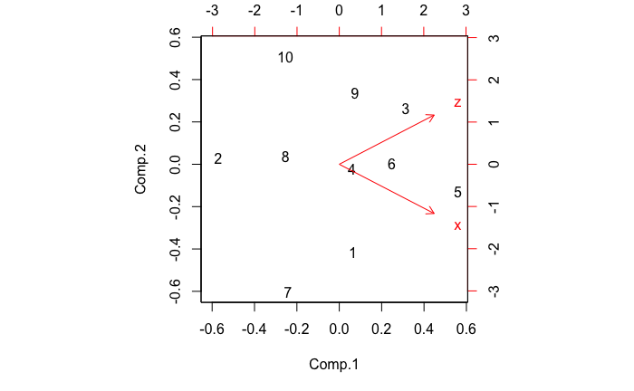

```r
biplot(fit)
```

Now, run a regression of Y on x,z, and Y on Comp.1, Comp.2

```r
fit1 <- lm(y~x+z,data=toypc)
fit2 <- lm(toypc$y~fit$scores)
fit3 <- lm(toypc$y~fit$scores[,1])
summary(fit1)
```

```
Call:
lm(formula = y ~ x + z, data = toypc)

Residuals:
    Min      1Q  Median      3Q     Max
-5.0037 -0.8776  0.7727  1.5321  2.6754

Coefficients:
            Estimate Std. Error t value Pr(>|t|)
(Intercept)   -2.551      3.135  -0.814    0.443
x              1.694      1.057   1.602    0.153
z              2.890      1.229   2.351    0.051 .
---
Signif. codes:
0 ‘***’ 0.001 ‘**’ 0.01 ‘*’ 0.05 ‘.’ 0.1 ‘ ’ 1

Residual standard error: 2.811 on 7 degrees of freedom
Multiple R-squared:  0.7263,    Adjusted R-squared:  0.6481
F-statistic: 9.289 on 2 and 7 DF,  p-value: 0.01072
```

```r
summary(fit2)
```

```
Call:
lm(formula = toypc$y ~ fit$scores)

Residuals:
    Min      1Q  Median      3Q     Max
-5.0037 -0.8776  0.7727  1.5321  2.6754

Coefficients:
                 Estimate Std. Error t value Pr(>|t|)
(Intercept)       10.3300     0.8889  11.621 7.89e-06 ***
fit$scoresComp.1   3.0382     0.7083   4.290  0.00361 **
fit$scoresComp.2   0.5755     1.3639   0.422  0.68573
---
Signif. codes:
0 ‘***’ 0.001 ‘**’ 0.01 ‘*’ 0.05 ‘.’ 0.1 ‘ ’ 1

Residual standard error: 2.811 on 7 degrees of freedom
Multiple R-squared:  0.7263,    Adjusted R-squared:  0.6481
F-statistic: 9.289 on 2 and 7 DF,  p-value: 0.01072
```

```r
summary(fit3)
```

```
Call:
lm(formula = toypc$y ~ fit$scores[, 1])

Residuals:
    Min      1Q  Median      3Q     Max
-5.4992 -0.7215  0.7373  1.4772  2.6797

Coefficients:
                Estimate Std. Error t value Pr(>|t|)
(Intercept)      10.3300     0.8420  12.268 1.81e-06 ***
fit$scores[, 1]   3.0382     0.6709   4.529  0.00193 **
---
Signif. codes:
0 ‘***’ 0.001 ‘**’ 0.01 ‘*’ 0.05 ‘.’ 0.1 ‘ ’ 1

Residual standard error: 2.663 on 8 degrees of freedom
Multiple R-squared:  0.7194,    Adjusted R-squared:  0.6843
F-statistic: 20.51 on 1 and 8 DF,  p-value: 0.001928
```

Now, open up the Olymp88sas.dat dataset

```r
olymp <- read.csv("Olymp88sas.dat")
summary(olymp)
```

```
     r100m          longjump          shot
 Min.   :10.62   Min.   :5.830   Min.   : 9.71
 1st Qu.:11.02   1st Qu.:6.985   1st Qu.:12.99
 Median :11.18   Median :7.085   Median :14.05
 Mean   :11.22   Mean   :7.095   Mean   :13.85
 3rd Qu.:11.45   3rd Qu.:7.367   3rd Qu.:14.86
 Max.   :12.12   Max.   :7.720   Max.   :16.60
    highjump         r400m           h110m
 Min.   :1.700   Min.   :47.44   Min.   :14.18
 1st Qu.:1.940   1st Qu.:48.35   1st Qu.:14.73
 Median :1.970   Median :49.21   Median :15.00
 Mean   :1.974   Mean   :49.37   Mean   :15.11
 3rd Qu.:2.030   3rd Qu.:49.99   3rd Qu.:15.39
 Max.   :2.270   Max.   :52.32   Max.   :17.05
     discus         polevlt         javelin
 Min.   :27.10   Min.   :2.600   Min.   :39.10
 1st Qu.:38.88   1st Qu.:4.525   1st Qu.:55.06
 Median :42.09   Median :4.700   Median :58.66
 Mean   :41.91   Mean   :4.676   Mean   :58.84
 3rd Qu.:44.69   3rd Qu.:4.900   3rd Qu.:63.75
 Max.   :50.66   Max.   :5.700   Max.   :72.60
     r1500m          score
 Min.   :256.6   Min.   :5339
 1st Qu.:266.7   1st Qu.:7532
 Median :272.4   Median :7864
 Mean   :276.2   Mean   :7783
 3rd Qu.:285.9   3rd Qu.:8177
 Max.   :303.2   Max.   :8488
```

Let’s use the “psych” package to run PCA here.

```
Parallel analysis suggests that the number of factors =  NA  and the number of components =  2
```

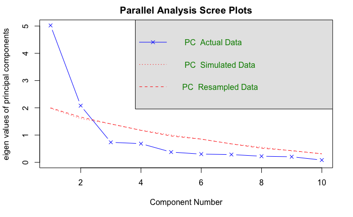

```r
library("psych")
fa.parallel(olymp[,-11],fa="pc")
```

Note: How do you plot the loadings?

[figure not shown]

Now, let us run cluster analysis. Install the following packages: “cluster, NbClust, flexclust, fMultivar, ggplot2, and rattle packages”

```r
forcluster <- c("cluster","NbClust","flexclust","fMultivar","rattle")
install.packages(forcluster)
```

Import the Public Utilities Dataset

```r
putil <- read.csv("Public Utilities.dat")
summary(putil)
```

```
    Coverage         Return           Cost
 Min.   :0.750   Min.   : 6.40   Min.   : 96.0
 1st Qu.:1.042   1st Qu.: 9.20   1st Qu.:148.5
 Median :1.110   Median :11.05   Median :170.5
 Mean   :1.114   Mean   :10.74   Mean   :168.2
 3rd Qu.:1.190   3rd Qu.:12.35   3rd Qu.:195.8
 Max.   :1.490   Max.   :15.40   Max.   :252.0

      Load            Peak            Sales
 Min.   :49.80   Min.   :-2.200   Min.   : 3300
 1st Qu.:53.77   1st Qu.: 1.450   1st Qu.: 6458
 Median :56.35   Median : 3.000   Median : 8024
 Mean   :56.98   Mean   : 3.241   Mean   : 8914
 3rd Qu.:60.30   3rd Qu.: 5.350   3rd Qu.:10128
 Max.   :67.60   Max.   : 9.200   Max.   :17441

    Nuclear          Fuel
 Min.   : 0.0   Min.   :0.309
 1st Qu.: 0.0   1st Qu.:0.630
 Median : 0.0   Median :0.960
 Mean   :12.0   Mean   :1.103
 3rd Qu.:24.6   3rd Qu.:1.516
 Max.   :50.2   Max.   :2.116

                  Company
 Arizona Public       : 1
 Boston Edison        : 1
 Central Louisiana    : 1
 Commonwealth Edison  : 1
 Consolidated Edison  : 1
 Florida Power & Light: 1
 (Other)              :16
```

When using clustering, it is always good to standardize the variables, so you are dealing with variables in the same scale.

```r
row.names(putil) <- putil$Company # use Company for row names
putils <- scale(putil[,-9]) # only use numeric columns
summary(putils)
```

```
    Coverage            Return             Cost
 Min.   :-1.97327   Min.   :-1.9324   Min.   :-1.75235
 1st Qu.:-0.38800   1st Qu.:-0.6846   1st Qu.:-0.47781
 Median :-0.02217   Median : 0.1398   Median : 0.05628
 Mean   : 0.00000   Mean   : 0.0000   Mean   : 0.00000
 3rd Qu.: 0.41141   3rd Qu.: 0.7191   3rd Qu.: 0.66927
 Max.   : 2.03732   Max.   : 2.0782   Max.   : 2.03485
      Load              Peak              Sales
 Min.   :-1.6088   Min.   :-1.74486   Min.   :-1.5814
 1st Qu.:-0.7178   1st Qu.:-0.57433   1st Qu.:-0.6918
 Median :-0.1406   Median :-0.07726   Median :-0.2507
 Mean   : 0.0000   Mean   : 0.00000   Mean   : 0.0000
 3rd Qu.: 0.7448   3rd Qu.: 0.67637   3rd Qu.: 0.3420
 Max.   : 2.3812   Max.   : 1.91104   Max.   : 2.4020
    Nuclear             Fuel
 Min.   :-0.7146   Min.   :-1.4273
 1st Qu.:-0.7146   1st Qu.:-0.8501
 Median :-0.7146   Median :-0.2567
 Mean   : 0.0000   Mean   : 0.0000
 3rd Qu.: 0.7504   3rd Qu.: 0.7436
 Max.   : 2.2749   Max.   : 1.8221
```

Now run the cluster analysis by 1. Calculating distance 2. Using Wards distance to form clusters

```r
d <- dist(putils)
summary(d)
```

```
   Min. 1st Qu.  Median    Mean 3rd Qu.    Max.
  1.384   3.137   3.902   3.865   4.573   6.461
```

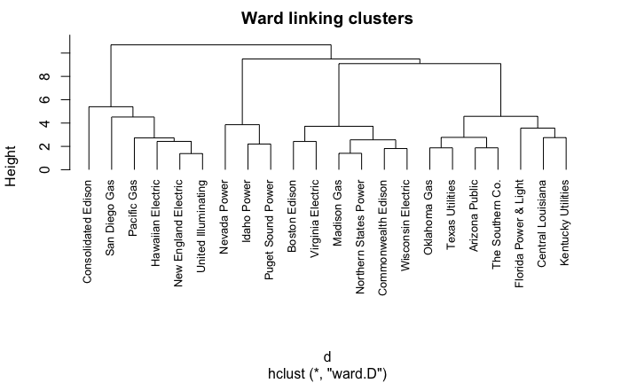

```r
fit.w <- hclust(d,method="ward.D")
plot(fit.w,hang=-1,cex=0.8,main="Ward linking clusters")
```

```r
clusters <- cutree(fit.w,k=4)
table(clusters)
```

```
clusters
1 2 3 4
7 6 6 3
```

```r
aggregate(putil,by=list(cluster=clusters),mean) #original form
```

```
argument is not numeric or logical: returning NAargument is not numeric or logical: returning NAargument is not numeric or logical: returning NAargument is not numeric or logical: returning NA
```

| cluster | Coverage | Return | Cost | Load | Peak | Sales | Nuclear | Fuel | Company |
| --- | --- | --- | --- | --- | --- | --- | --- | --- | --- |
| 1 | 1.207143 | 12.485714 | 127.5714 | 55.47143 | 1.714286 | 10163.14 | 3.214286 | 0.8744286 | NA |
| 2 | 1.075000 | 11.283333 | 181.3333 | 55.80000 | 3.500000 | 7087.50 | 36.116667 | 0.9021667 | NA |
| 3 | 1.100000 | 9.083333 | 174.8333 | 60.98333 | 3.216667 | 5988.00 | 4.133333 | 1.8381667 | NA |
| 4 | 1.003333 | 8.866667 | 223.3333 | 54.83333 | 6.333333 | 15504.67 | 0.000000 | 0.5656667 | NA |

```r
aggregate(putils,by=list(cluster=clusters),mean) #scaled form
```

| cluster | Coverage | Return | Cost | Load | Peak | Sales | Nuclear | Fuel |
| --- | --- | --- | --- | --- | --- | --- | --- | --- |
| 1 | 0.50431607 | 0.7795509 | -0.9858961 | -0.3375463 | -0.489576922 | 0.3518600 | -0.5232108 | -0.4105368 |
| 2 | -0.21186202 | 0.2437423 | 0.3192786 | -0.2638946 | 0.083088555 | -0.5145222 | 1.4362066 | -0.3606569 |
| 3 | -0.07636887 | -0.7366283 | 0.1614784 | 0.8979888 | -0.007774368 | -0.8242419 | -0.4684793 | 1.3224995 |
| 4 | -0.60027572 | -0.8331800 | 1.3389101 | -0.4805802 | 0.991717777 | 1.8565214 | -0.7146294 | -0.9657660 |

Now plot the results

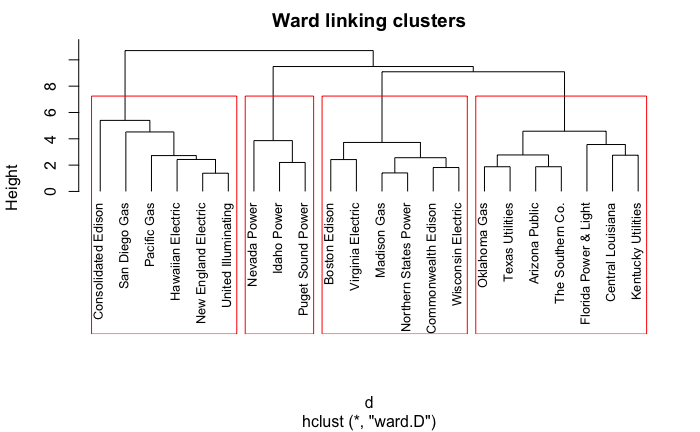

```r
plot(fit.w,hang=-1,cex=0.8,main="Ward linking clusters")
rect.hclust(fit.w,k=4)
```

Let us now perform k-means clustering. Note that you have to specify the number of clusters

```
*** : The Hubert index is a graphical method of determining the number of clusters.
                In the plot of Hubert index, we seek a significant knee that corresponds to a
                significant increase of the value of the measure i.e the significant peak in Hubert
                index second differences plot.
```

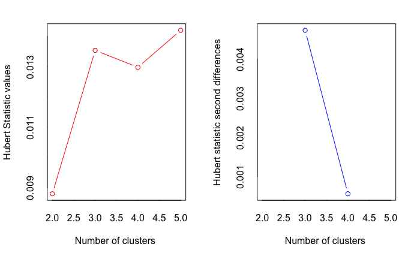

```
*** : The D index is a graphical method of determining the number of clusters.
                In the plot of D index, we seek a significant knee (the significant peak in Dindex
                second differences plot) that corresponds to a significant increase of the value of
                the measure.

* Among all indices:
* 3 proposed 2 as the best number of clusters
* 6 proposed 3 as the best number of clusters
* 7 proposed 4 as the best number of clusters
* 7 proposed 5 as the best number of clusters

                   ***** Conclusion *****

* According to the majority rule, the best number of clusters is  4
```

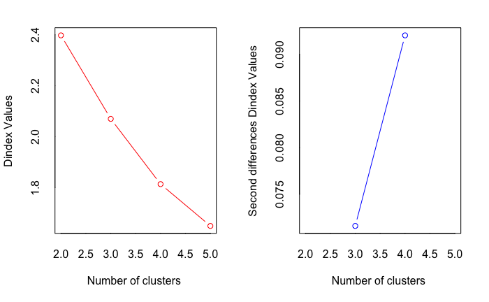

```r
library(NbClust)
set.seed(1234)
devAskNewPage(ask=T)
nc <- NbClust(putils,min.nc=2,max.nc=5,method="kmeans")
```